# kolejkeR 1.1

## Get access to data regarding queues in municipal offices in Warsaw

The city hall of Warsaw made a variety of data public [here](https://api.um.warszawa.pl). Everyone is welcome to access the data via API, using JSON file format. One of the datasets contains the information about queues in municipal offices in Warsaw, ie. expected times, open counters and amount of people waiting.

`kolejkeR` is an R wrapper around the API, developed as a project for Advanced R classes at the Warsaw University of Technology. It’s suitable both for further data processing and analysis, as well as for quick acquirement of information helpful for everyday life in Warsaw.

## Whats new?

- SHINY
- AppVeyor
- Amount of dependencies reduced
- Dataset of archived data for your own exploration
- New function for collecting all data
- Model for predictions

## Shiny

[figure not shown]

[ShinyApps](https://sowiks2711.shinyapps.io/kolejkershiny/)

## Reduced amount of dependencies

**Imports:**

- **jsonlite**
- **glue**

## Dataset

```r
data("warsaw_queues")
```

| name | time | date | status | czasObslugi | lp | idGrupy | liczbaCzynnychStan | nazwaGrupy | literaGrupy | liczbaKlwKolejce | aktualnyNumer |
| --- | --- | --- | --- | --- | --- | --- | --- | --- | --- | --- | --- |
| USC_Andersa | 08:00 | 2020-12-30 | 1 | 10 | 1 | 135 | 0 | T: Odbiór odpisu po sprostowaniu lub uzupełnieniu | T | 0 |  |
| USC_Andersa | 08:00 | 2020-12-30 | 1 | 10 | 2 | 127 | 0 | Z: Zgłoszenie zgonu na podstawie karty zgonu | Z | 0 |  |
| USC_Andersa | 08:00 | 2020-12-30 | 1 | 10 | 3 | 119 | 0 | P: Oświadczenie o powrocie do nazwiska noszonego przed ślubem | P | 0 |  |
| USC_Andersa | 08:00 | 2020-12-30 | 0 | 10 | 4 | 128 | 0 | S: Sprostowanie lub uzupełnienie aktu | S | 0 |  |
| USC_Andersa | 08:00 | 2020-12-30 | 1 | 10 | 5 | 118 | 0 | I: Zmiana imienia lub nazwiska w trybie administracyjnym | I | 0 |  |
| USC_Andersa | 08:00 | 2020-12-30 | 0 | 10 | 6 | 130 | 0 | Z: Sprostowanie lub uzupełnienie aktu zgonu | Z | 0 |  |

## New function

```r
append_api_data_to_csv(filename)
```

1. Collects data from Warsaw queue api from all offices
2. Writes it to csv file

## Example

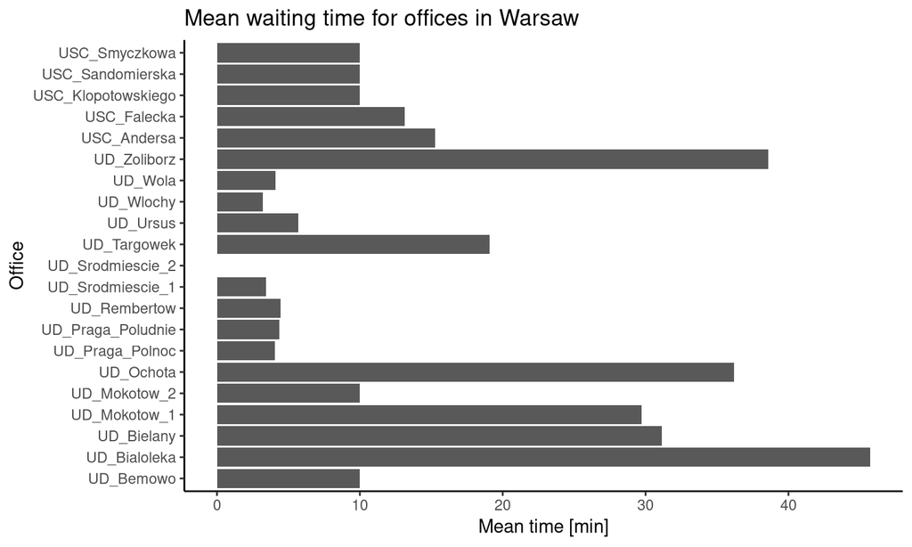